# Homework 5

Kevin O’Connell

2023-09-29

1. Read the data file aircrashesFullData.csv using the read_csv() function in tidyverse.

```r
library(tidyverse)
crash <- read.csv("C:\\RStudio_MTH_209\\aircrashesFullData.csv")
library(conflicted)
conflict_prefer("lag","dplyr")
```

```
## [conflicted] Will prefer dplyr::lag over any other package.
```

```r
conflict_prefer("filter", "dplyr")
```

```
## [conflicted] Will prefer dplyr::filter over any other package.
```

2. Get a glimpse of the data and indicate the number of observations and the number of variables in the data.

```r
glimpse(crash)
```

```
## Rows: 5,030
## Columns: 12
## $ Year                    <int> 1908, 1909, 1912, 1913, 1913, 1913, 1915, 1915…
## $ Quarter                 <chr> "Qtr 3", "Qtr 3", "Qtr 3", "Qtr 3", "Qtr 3", "…
## $ Month                   <chr> "September", "September", "July", "August", "S…
## $ Day                     <int> 17, 7, 12, 6, 9, 17, 5, 3, 28, 24, 1, 21, 28, …
## $ Country.Region          <chr> "Virginia", "France?", "New", "British", "N/A"…
## $ Aircraft.Manufacturer   <chr> "Wright Flyer", "Wright", "Dirigible?", "Curti…
## $ Aircraft                <chr> "Wright Flyer III?", "Wright ByplaneSC1", "Dir…
## $ Location                <chr> "Fort Myer Virginia", "Juvisy-sur-Orge France?…
## $ Operator                <chr> "Army U.S. - Military", "N/A", "Navy U.S. - Je…
## $ Sum.of.Ground           <int> 0, 0, 0, 0, 0, 0, 0, 0, 0, 0, 0, 0, 0, 0, 0, 0…
## $ Sum.of.Fatalities..air. <int> 1, 1, 5, 1, 14, 28, 17, 19, 20, 22, 19, 27, 20…
## $ Sum.of.Aboard           <int> 2, 1, 5, 1, 20, 28, 41, 19, 20, 22, 19, 28, 20…
```

There are 12 variables and 5,030 observations

3. Create a histogram for the Year and summarize the distribution of the histogram.

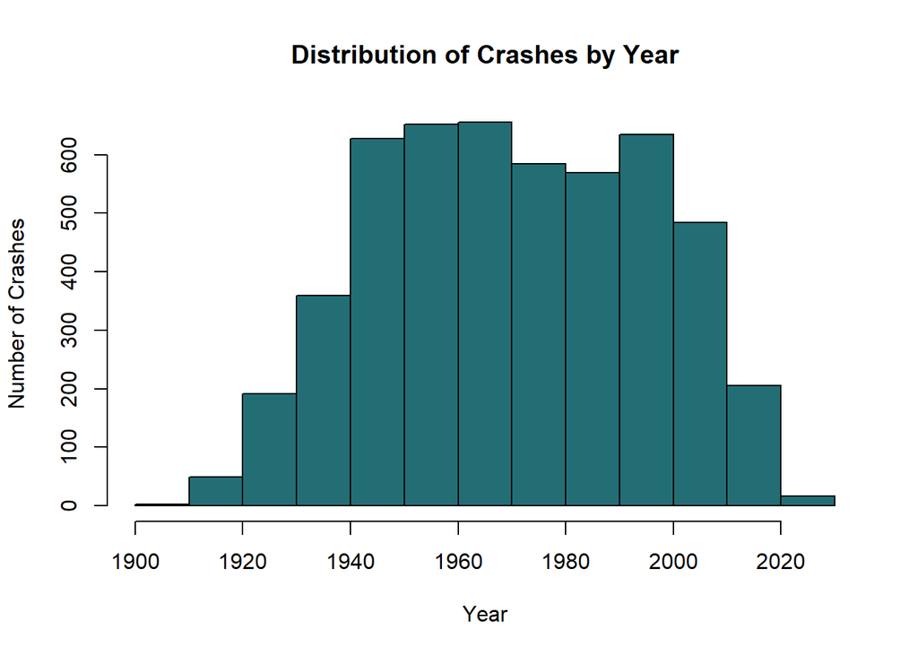

```r
hist(crash$Year,
     main = "Distribution of Crashes by Year",
     xlab = "Year",
     ylab = "Number of Crashes",
     col = "#236E75")
```

The distribution of crashes by year is slightly skewed left, which makes sense because there were less air vehicles in the early 1900s. The distribution is bimodal, with one mode at year 1960 and on at year 1990. The center of the distribution lies around 1960, as the majority of air crashes occurred between the years 1940 and 2000. This is likely because the technology of aircraft was being developed throughout the 20th century and has reached a very safe capacity in th 21st century, which is shown by the decrease in crashes.

4. Create a bar plot for the Month. You should make sure the order of bars is in ascending order (January, February, March, …, December) and the text for each month doesn’t overlap others. Summarize your findings based on the plot.

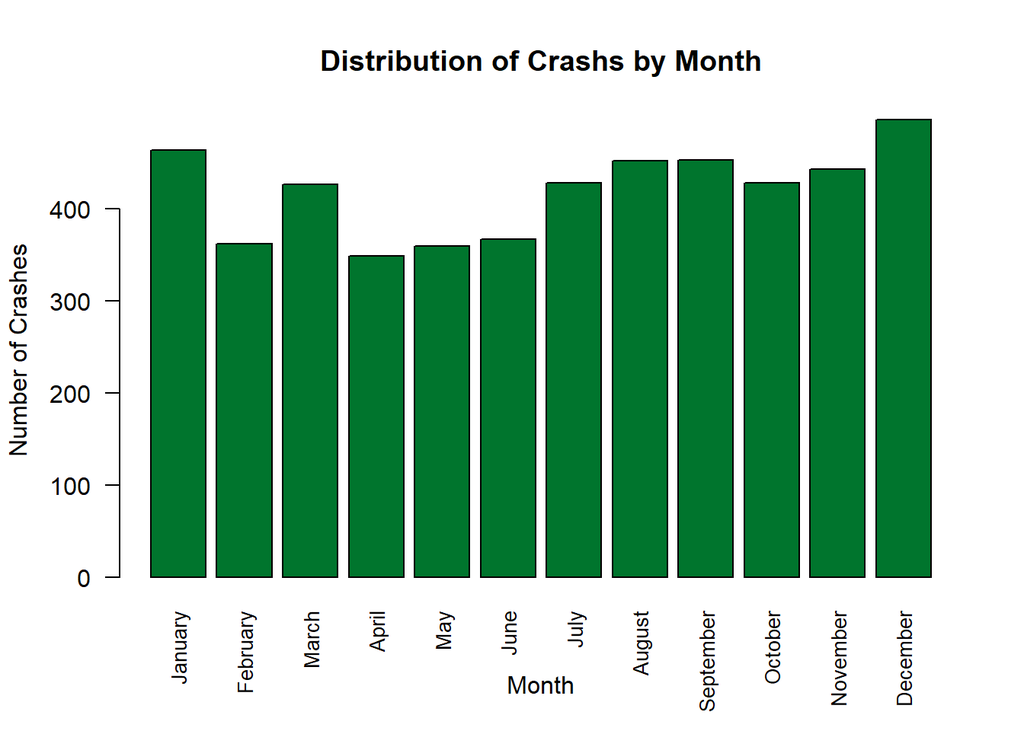

```r
crash$Month <- factor(crash$Month, levels = month.name)

barplot(table(crash$Month),
        col = "#00752D",
        main = "Distribution of Crashs by Month",
        xlab = "Month",
        ylab = "Number of Crashes", cex.names = .85, las = 2)
```

5. Create a pie chart for the Quarter, including percentages for each slice of pie.

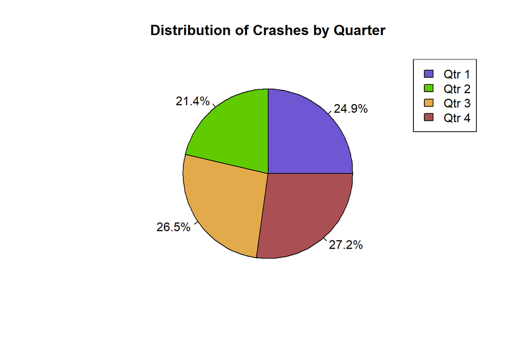

```r
Q <-table(crash$Quarter)

percent <- round(100*Q/sum(Q), 1)

pie_labels <- paste(percent, "%", sep="")

pie(Q, main = "Distribution of Crashes by Quarter",
    labels = pie_labels,
    col = c("#6f56d2", "#5fcb00", "#e3aa4b", "#aa4f54"))
legend("topright", c("Qtr 1", "Qtr 2", "Qtr 3", "Qtr 4"), cex = 1, fill = c("#6f56d2", "#5fcb00", "#e3aa4b", "#aa4f54"))
```

In the following questions, we will focus on only the Country/Region of “California.”

6. Subset the original dataset to get only the California data. Here, you should assign a new name for this California data.

```r
california <- filter(crash, Country.Region == "California")
```

7. Create a boxplot that shows the distribution of the Sum of Aboard based on the Quarters. Discuss what you find based on the boxplots.

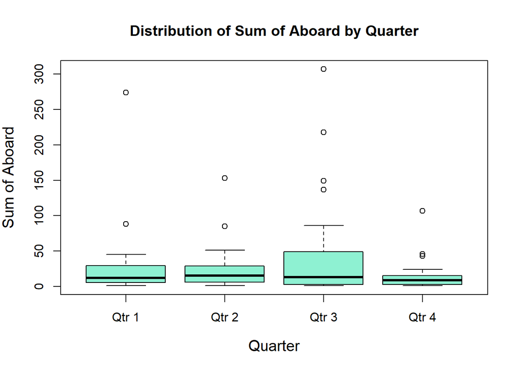

```r
boxplot(california$Sum.of.Aboard ~ california$Quarter,
       main = "Distribution of Sum of Aboard by Quarter",
       xlab = "Quarter",
       ylab = "Sum of Aboard",
       cex.lab = 1.25, cex.axis = 1, col = "#8ef1d2")
```

8. Create a boxplot that shows the distribution of the Sum of Fatalities (air) based on the Quarters. Discuss what you find based on the boxplots.

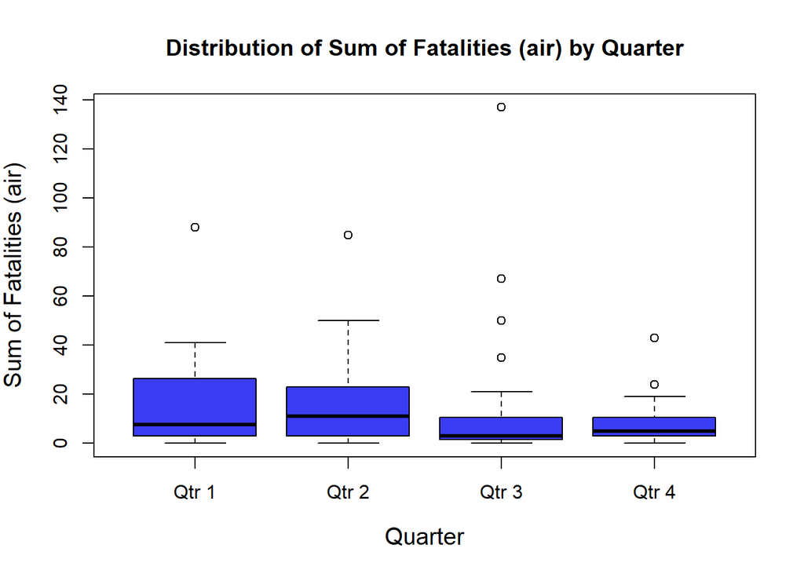

```r
boxplot(california$Sum.of.Fatalities..air. ~ california$Quarter,
       main = "Distribution of Sum of Fatalities (air) by Quarter",
       xlab = "Quarter",
       ylab = "Sum of Fatalities (air)",
       cex.lab = 1.25, cex.axis = 1, col = "#3a3df2")
```

Quarters 1 and 2 have the largest distributions of Air Fatalities, with Quarter 2 having the largest median of any quarter (~10). Quarter 3 has an outlier of 120+ air fatalities, which likely represents a commercial flight crash. Quarters 1 and 2 represent the first 6 months of a year, including winter, so harsh weather could be a factor that causes more aircraft crashes and thus more fatalities.

9. Create a boxplot that shows the distribution of the Sum of Ground based on the Quarters. Discuss what you find based on the boxplots.

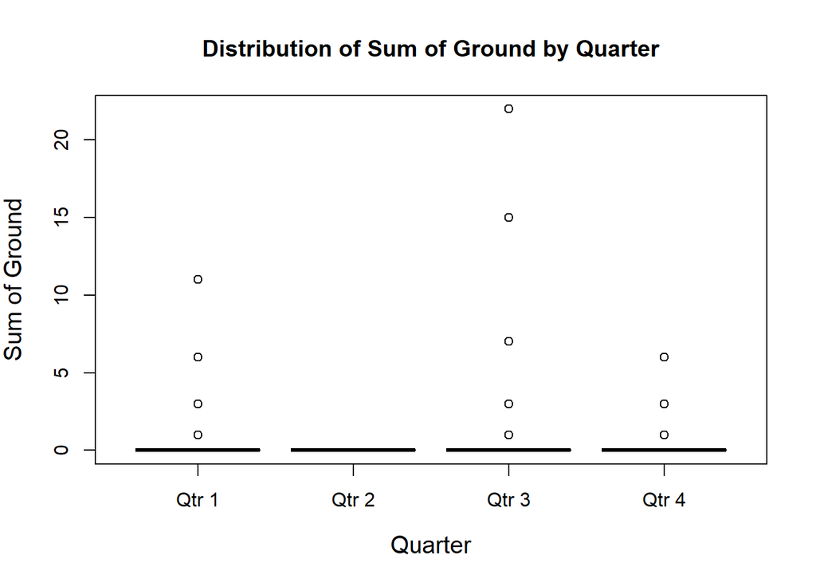

```r
boxplot(california$Sum.of.Ground ~ california$Quarter,
       main = "Distribution of Sum of Ground by Quarter",
       xlab = "Quarter",
       ylab = "Sum of Ground",
       cex.lab = 1.25, cex.axis = 1, col = "#AD6903")
```

```r
summary(california$Sum.of.Ground)
```

```
##    Min. 1st Qu.  Median    Mean 3rd Qu.    Max.
##  0.0000  0.0000  0.0000  0.7679  0.0000 22.0000
```

Based on the bar plot and the summary of the data, 75% of values for Sum of Ground are 0. This means that a majority of crashes did not cause any ground fatalities, making the crashes that did cause ground fatalities become outliers. This makes sense because we are studying aircraft crashes, so most fatalities would occur in the air.

10. Compare the boxplots you have in Questions 6, 7, and 8. Do you see a similar trend? Explain. Summarize your findings.

I see a trend between the type of fatalities for each quarter. In aircraft crashes, most deaths likely occur while the plane is still in air do to fires, explosions, or loss of air pressure. Ground fatalities are less of a concern as those have more to do with the aftermath of a crash and the injuries sustained while the craft was still in the air.

11. Create a scatterplot that shows the relationship between the Sum of Ground (independent variable) and the Sum of Fatalities (air) (dependent variable). Comment on the scatterplot. Are you surprised to see the pattern in the plot? Why or why not?

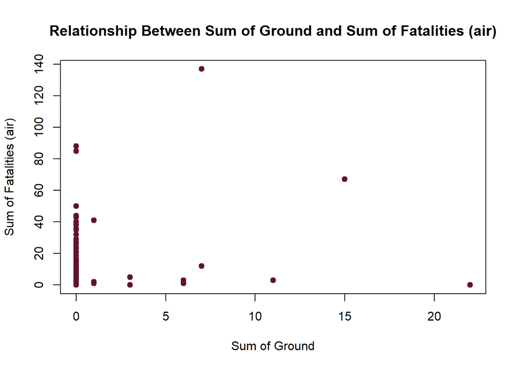

```r
plot(x=california$Sum.of.Ground, y=california$Sum.of.Fatalities..air.,
     main = "Relationship Between Sum of Ground and Sum of Fatalities (air)",
     xlab = "Sum of Ground",
     ylab = "Sum of Fatalities (air)",
     col = "#611230", pch = 19)
```

12. Create a time series plot (lines) that shows the pattern of the Sum of Fatalities (air) for the Country/Region of China, Colombia, France, and Mexico from 2000 to 2020. Your time series plot should have 4 lines. (Hint: You need to subset the original data to get the data needed for each line.)

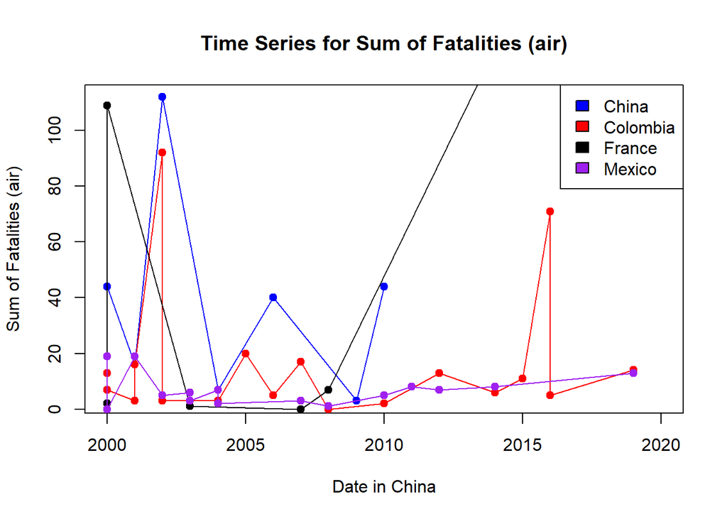

```r
Date <- 2000:2020
China <-crash[crash$Country.Region == "China" & crash$Year %in% c(2000:2020),]
Colombia <- crash[crash$Country.Region == "Colombia" & crash$Year %in% c(2000:2020),]
France <- crash[crash$Country.Region == "France" & crash$Year %in% c(2000:2020),]
Mexico <- crash[crash$Country.Region == "Mexico" & crash$Year %in% c(2000:2020),]

plot(China$Year, China$Sum.of.Fatalities..air., type = "o", col ="blue", pch = 19,
     main = "Time Series for Sum of Fatalities (air)",
     xlab = "Date in China",
     ylab = "Sum of Fatalities (air)", xlim = c(2000, 2020))
lines(Colombia$Year, Colombia$Sum.of.Fatalities..air., type = "o", col = "red", pch = 19)
lines(France$Year, France$Sum.of.Fatalities..air., type = "o", col = "black", pch = 19)
lines(Mexico$Year, Mexico$Sum.of.Fatalities..air., type = "o", col = "purple", pch = 19)
legend("topright", c("China", "Colombia", "France", "Mexico"), cex = 1, fill = c("blue", "red", "black", "purple"))
```